# Test Hourly Gap-Filling

KM Hall

6/5/2022

The purpose of this R Markdown notebook is to examine the flags created for the met_hourly_gap_filled.csv file produced in the anomalize_hourly_met_data.R program. There were two types of flags: 1. flags when a variable’s hourly data was missing in the raw data, but the hourly record is present in the data; and 2. there was no hourly record in the raw data.

In the second case, missing hourly records were produced and a no_record_flag was set to TRUE. Except for precipitation (ppt), data was then produced for the record using a simple gap-filling method that looked at a station’s mean for each variable on the given julian day and hour of the missing data. Missing ppt data was gap-filled with a value of 0.

```r
library(lubridate)
library(tidyverse)
library(kableExtra)

met <- read_csv("../data/processed_data/met_hourly_gap_filled.csv") %>%
  mutate(sta = as.factor(sta))
```

```r
rec_ct <- met %>%
  group_by(sta) %>%
  summarize(n_records = n()) %>%
  ungroup()
```

A no_record_flag of TRUE means that there was not a record in the raw data. There will not be any NAs for the no_record_flag.

```r
met %>%
  group_by(sta, no_record_flag) %>%
  summarize(flag_count = n()) %>%
  left_join(rec_ct) %>%
  mutate(flag_percent = flag_count / n_records * 100) %>%
  select(-n_records) %>%
  kbl() %>%
  kable_styling(full_width = FALSE, position = "left")
```

| sta | no_record_flag | flag_count | flag_percent |
| --- | --- | --- | --- |
| 40 | FALSE | 294428 | 98.7827791 |
| 40 | TRUE | 3628 | 1.2172209 |
| 42 | FALSE | 283909 | 98.1460356 |
| 42 | TRUE | 5363 | 1.8539644 |
| 49 | FALSE | 200470 | 99.4276475 |
| 49 | TRUE | 1154 | 0.5723525 |
| 50 | FALSE | 172549 | 98.4194616 |
| 50 | TRUE | 2771 | 1.5805384 |

Flags showing how many records are missing for a particular variable in the raw data. TRUE means the data is missing in the raw data, but there is a record present. NA means that the record was not present in the raw data.

```r
met %>%
  pivot_longer(airt_miss:maxsol_miss, names_to = "flag", values_to = "flag_value") %>%
  group_by(sta, flag, flag_value) %>%
  summarize(flag_count = n()) %>%
  left_join(rec_ct) %>%
  mutate(flag_percent = flag_count / n_records * 100) %>%
  select(-n_records) %>%
  kbl() %>%
  kable_styling(full_width = FALSE, position = "left")
```

| sta | flag | flag_value | flag_count | flag_percent |
| --- | --- | --- | --- | --- |
| 40 | airt_miss | FALSE | 293124 | 98.3452774 |
| 40 | airt_miss | TRUE | 1304 | 0.4375017 |
| 40 | airt_miss | NA | 3628 | 1.2172209 |
| 40 | maxair_miss | FALSE | 267802 | 89.8495585 |
| 40 | maxair_miss | TRUE | 26626 | 8.9332206 |
| 40 | maxair_miss | NA | 3628 | 1.2172209 |
| 40 | maxsol_miss | FALSE | 267905 | 89.8841157 |
| 40 | maxsol_miss | TRUE | 26523 | 8.8986633 |
| 40 | maxsol_miss | NA | 3628 | 1.2172209 |
| 40 | minair_miss | FALSE | 267789 | 89.8451969 |
| 40 | minair_miss | TRUE | 26639 | 8.9375822 |
| 40 | minair_miss | NA | 3628 | 1.2172209 |
| 40 | minsol_miss | FALSE | 267531 | 89.7586360 |
| 40 | minsol_miss | TRUE | 26897 | 9.0241431 |
| 40 | minsol_miss | NA | 3628 | 1.2172209 |
| 40 | ppt_miss | FALSE | 291653 | 97.8517460 |
| 40 | ppt_miss | TRUE | 2775 | 0.9310331 |
| 40 | ppt_miss | NA | 3628 | 1.2172209 |
| 40 | rh_miss | FALSE | 289604 | 97.1642913 |
| 40 | rh_miss | TRUE | 4824 | 1.6184878 |
| 40 | rh_miss | NA | 3628 | 1.2172209 |
| 40 | sol_miss | FALSE | 283487 | 95.1119924 |
| 40 | sol_miss | TRUE | 10941 | 3.6707867 |
| 40 | sol_miss | NA | 3628 | 1.2172209 |
| 42 | airt_miss | FALSE | 282946 | 97.8131309 |
| 42 | airt_miss | TRUE | 963 | 0.3329047 |
| 42 | airt_miss | NA | 5363 | 1.8539644 |
| 42 | maxair_miss | FALSE | 267301 | 92.4047263 |
| 42 | maxair_miss | TRUE | 16608 | 5.7413092 |
| 42 | maxair_miss | NA | 5363 | 1.8539644 |

[output cut: 64 more lines]

Test the annual differences in select met variables when not gap-filled versus when gap-filled.

```r
met_flag_diffs <- met %>%
  mutate(year = year(dt)) %>%
  group_by(sta, year) %>%
  summarize(airt_ngf = mean(airt[airt_miss == FALSE], na.rm = TRUE),
            airt_gf = mean(airt),
            airt_diff = airt_ngf - airt_gf,
            minair_ngf = mean(minair[minair_miss == FALSE], na.rm = TRUE),
            minair_gf = mean(minair),
            minair_diff = minair_ngf - minair_gf,
            maxair_ngf = mean(maxair[maxair_miss == FALSE], na.rm = TRUE),
            maxair_gf = mean(maxair),
            maxair_diff = maxair_ngf - maxair_gf,
            rh_ngf = mean(rh[rh_miss == FALSE], na.rm = TRUE),
            rh_gf = mean(rh),
            rh_diff = rh_ngf - rh_gf,
            ppt_ngf = sum(ppt[ppt_miss == FALSE], na.rm = TRUE),
            ppt_gf = sum(ppt),
            ppt_diff = ppt_ngf - ppt_gf,)
```

[output not shown]

airt gap-fill testing:

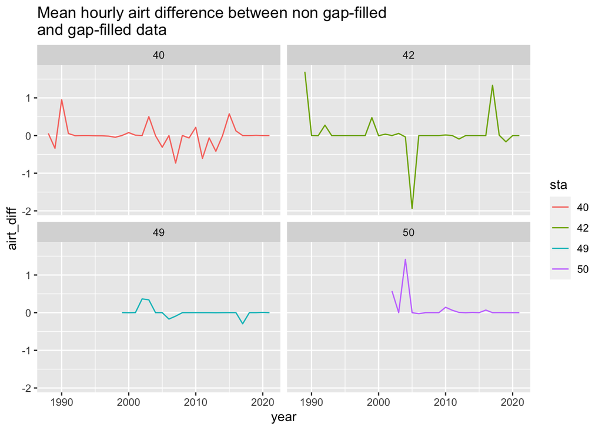

```r
ggplot(met_flag_diffs, aes(x = year, y = airt_diff, color=sta)) +
  geom_line() +
  facet_wrap(~sta) +
  ggtitle("Mean hourly airt difference between non gap-filled\nand gap-filled data")
```

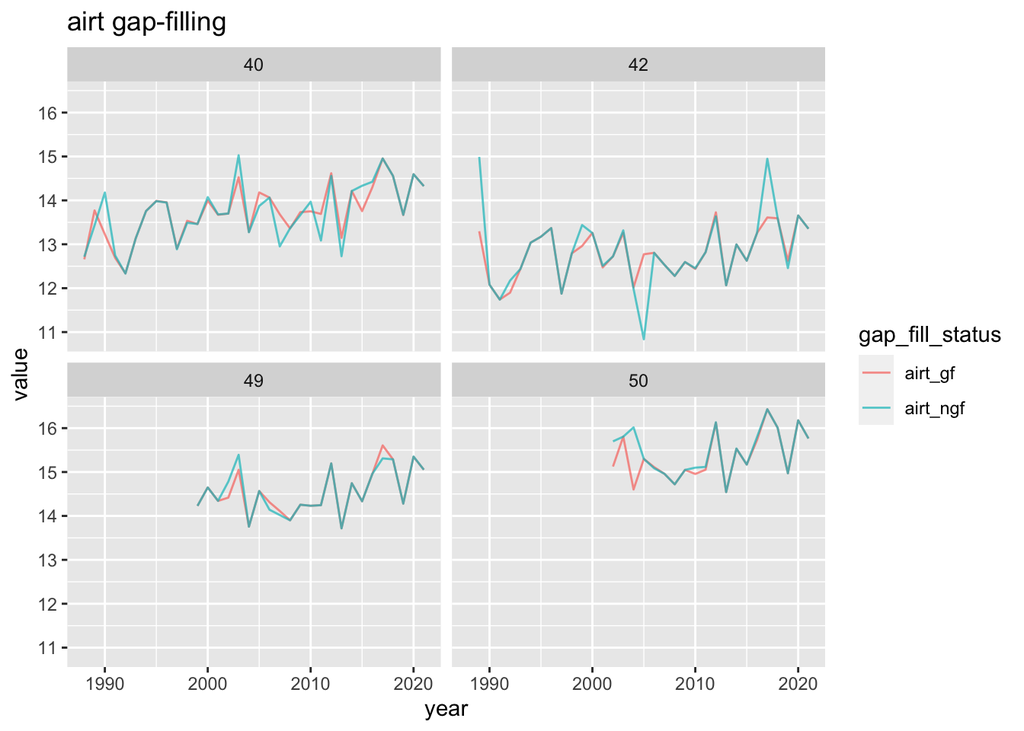

```r
met_flag_diffs %>%
  select(sta, year, airt_ngf, airt_gf) %>%
  pivot_longer(airt_ngf:airt_gf, names_to = 'gap_fill_status', values_to = 'value') %>%
  ggplot(aes(x = year, y = value, color = gap_fill_status)) +
  geom_line(alpha = 0.7) +
  facet_wrap(~ sta) +
  labs(title = "airt gap-filling")
```

minair gap-fill testing:

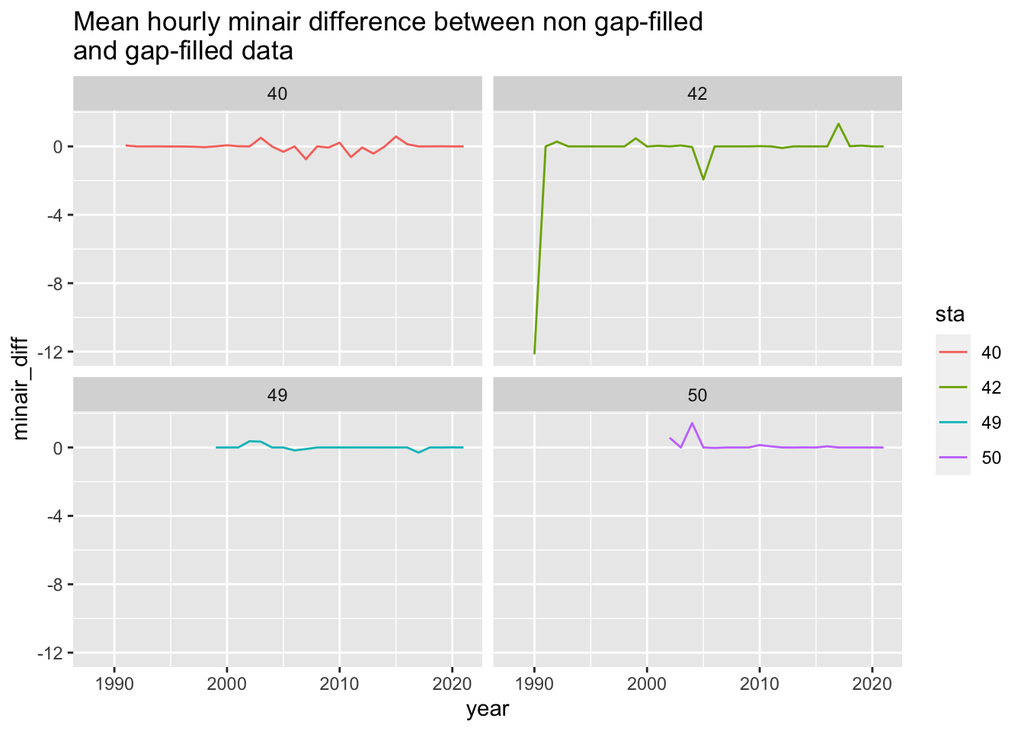

```r
ggplot(met_flag_diffs, aes(x = year, y = minair_diff, color=sta)) +
  geom_line() +
  facet_wrap(~sta) +
  ggtitle("Mean hourly minair difference between non gap-filled\nand gap-filled data")
```

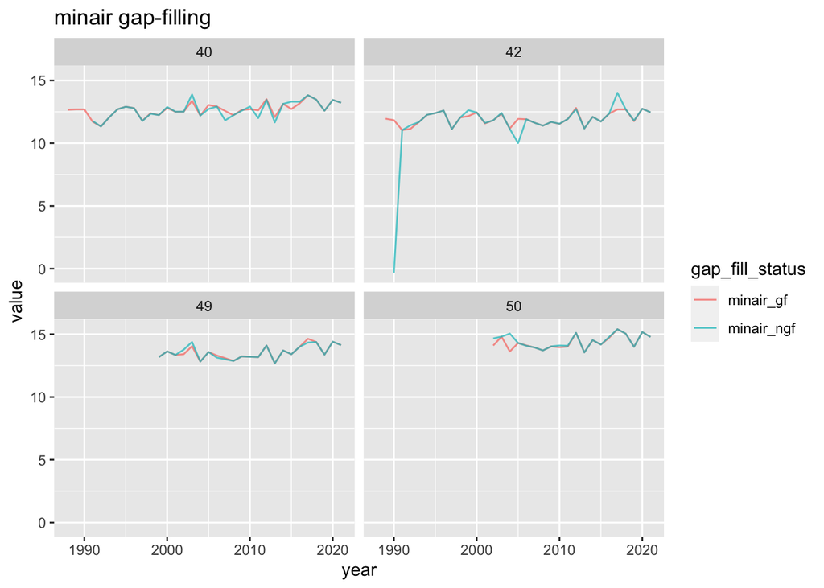

```r
met_flag_diffs %>%
  select(sta, year, minair_ngf, minair_gf) %>%
  pivot_longer(minair_ngf:minair_gf, names_to = 'gap_fill_status', values_to = 'value') %>%
  ggplot(aes(x = year, y = value, color = gap_fill_status)) +
  geom_line(alpha = 0.7) +
  facet_wrap(~ sta) +
  labs(title = "minair gap-filling")
```

The low values seen at the beginning of the time-series for station 42 is because minair was not calculated in the raw data. This artificially makes the gap-filling look bad. minair could be approximately calculated from hourly airt data for the early time period where it is missing in the raw data.

maxair gap-fill testing:

`## Warning: Removed 4 row(s) containing missing values (geom_path).`

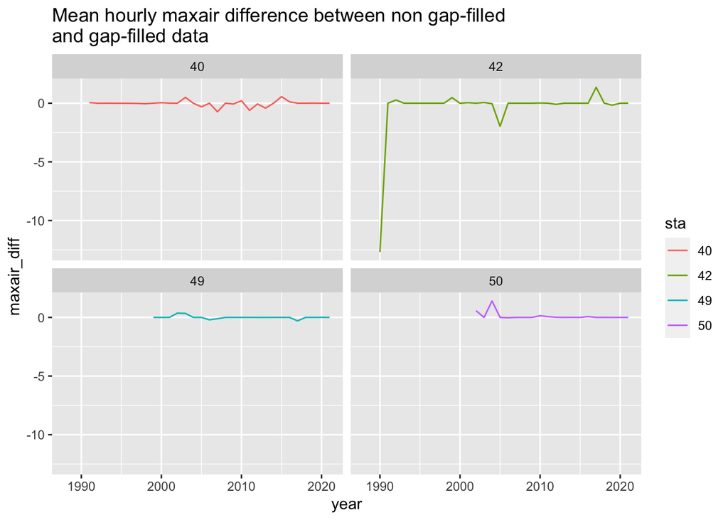

`## Warning: Removed 3 row(s) containing missing values (geom_path).`

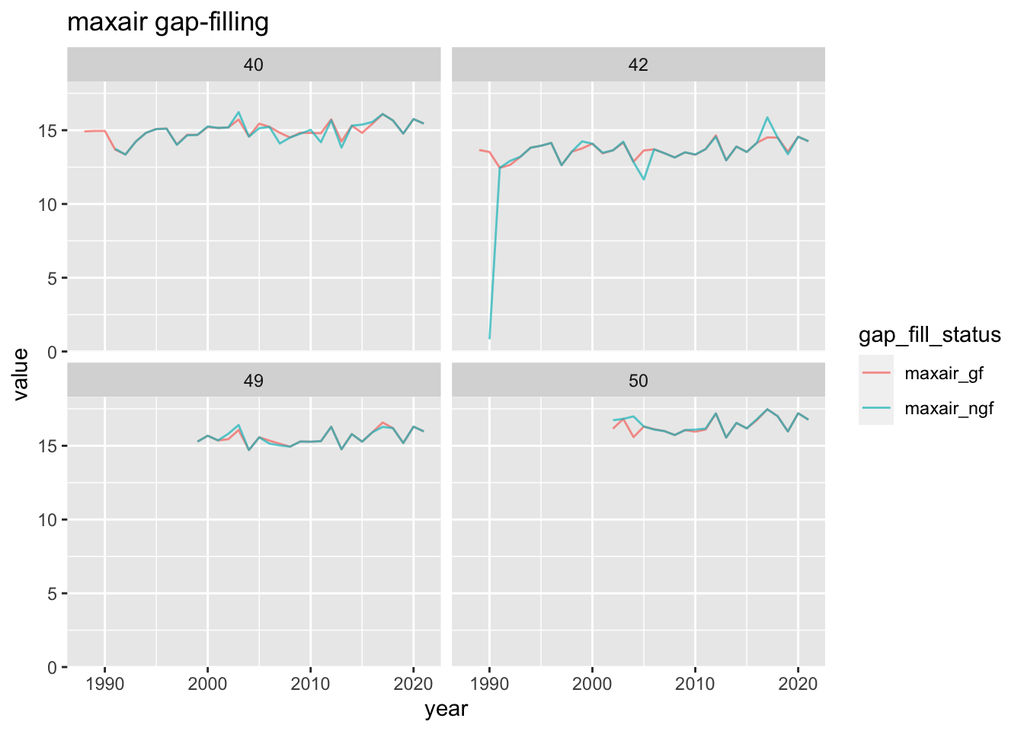

The low values seen at the beginning of the time-series for station 42 is because maxair was not calculated in the raw data. This artificially makes the gap-filling look bad. maxair could be approximately calculated from hourly airt data for the early time period where it is missing in the raw data.

rh gap-fill testing:

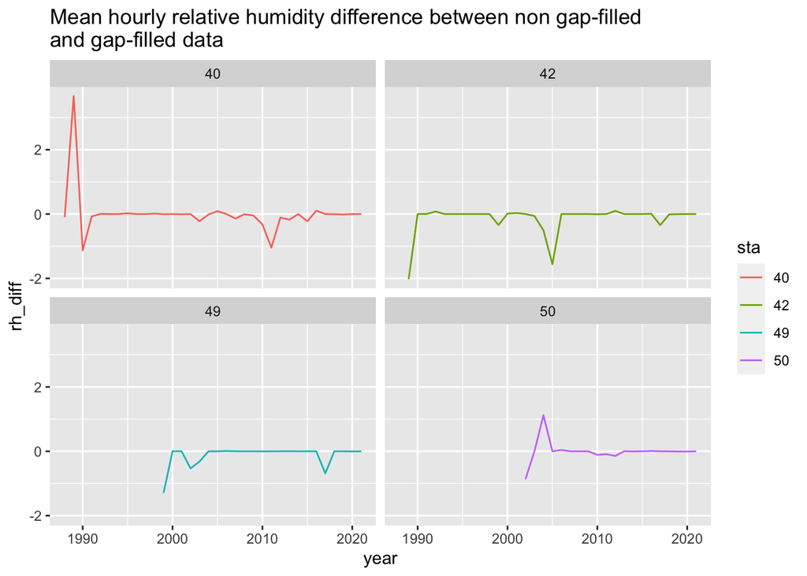

```r
ggplot(met_flag_diffs, aes(x = year, y = rh_diff, color=sta)) +
  geom_line() +
  facet_wrap(~sta) +
  ggtitle("Mean hourly relative humidity difference between non gap-filled\nand gap-filled data")
```

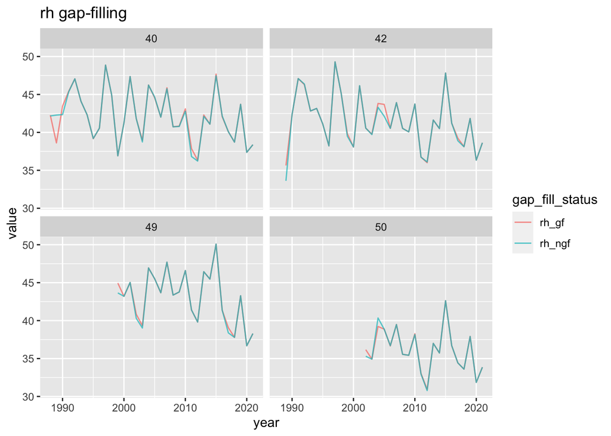

```r
met_flag_diffs %>%
  select(sta, year, rh_ngf, rh_gf) %>%
  pivot_longer(rh_ngf:rh_gf, names_to = 'gap_fill_status', values_to = 'value') %>%
  ggplot(aes(x = year, y = value, color = gap_fill_status)) +
  geom_line(alpha = 0.7) +
  facet_wrap(~ sta) +
  labs(title = "rh gap-filling")
```

ppt gap-fill testing:

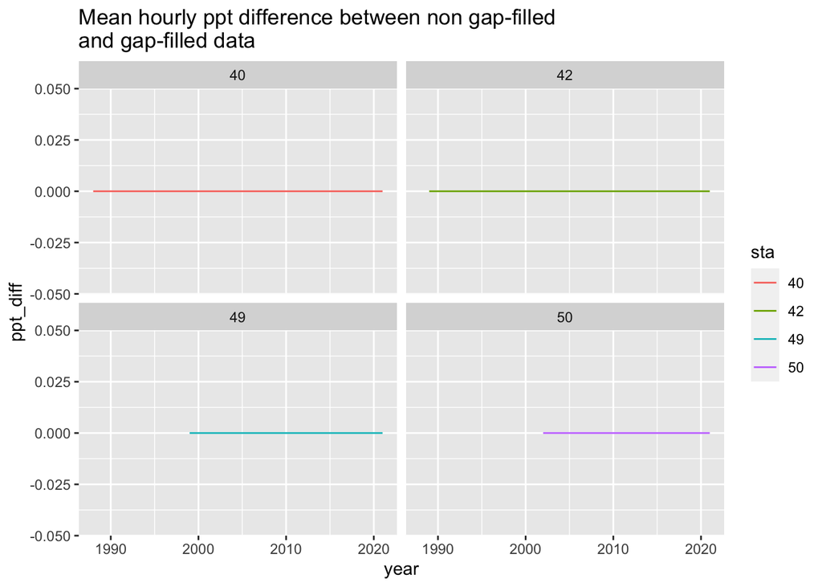

```r
ggplot(met_flag_diffs, aes(x = year, y = ppt_diff, color=sta)) +
  geom_line() +
  facet_wrap(~sta) +
  ggtitle("Mean hourly ppt difference between non gap-filled\nand gap-filled data")
```

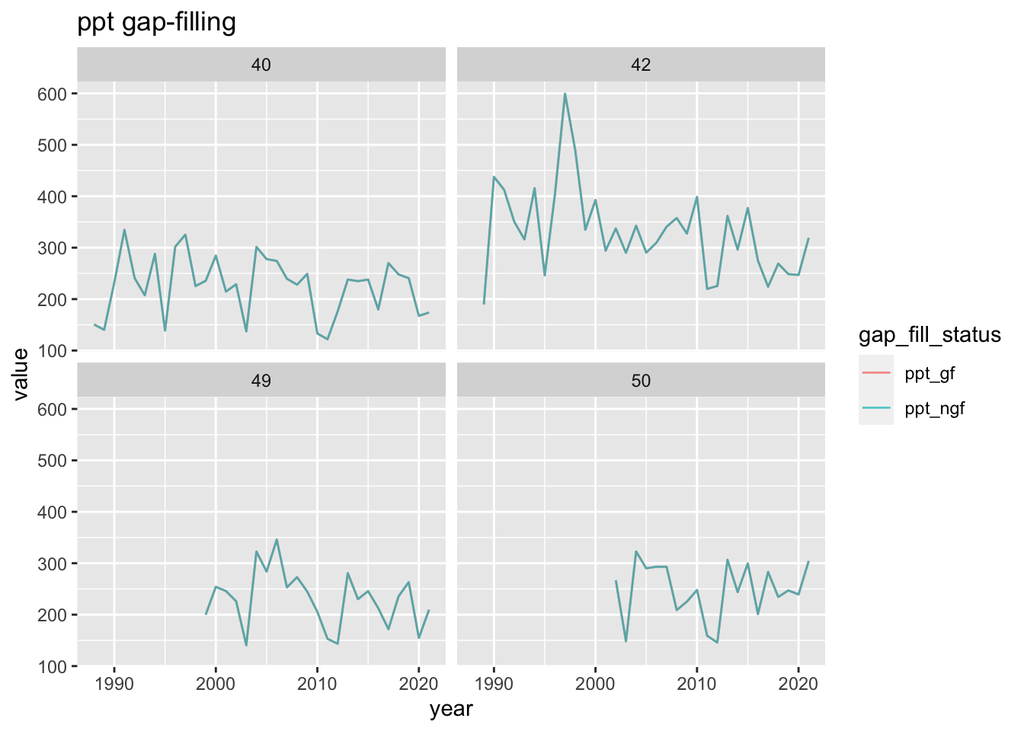

```r
met_flag_diffs %>%
  select(sta, year, ppt_ngf, ppt_gf) %>%
  pivot_longer(ppt_ngf:ppt_gf, names_to = 'gap_fill_status', values_to = 'value') %>%
  ggplot(aes(x = year, y = value, color = gap_fill_status)) +
  geom_line(alpha = 0.7) +
  facet_wrap(~ sta) +
  labs(title = "ppt gap-filling")
```

Gap-filling precipitation with a value of 0 does not change total precipitation when gap-filled.